# Data_visualization_HW_1

Elena Marochkina

2025-01-17

# 1. Read and prepare data

Data summary

| Name | Piped data |
| --- | --- |
| Number of rows | 916 |
| Number of columns | 74 |
| _______________________ |  |
| Column type frequency: |  |
| factor | 39 |
| numeric | 35 |
| ________________________ |  |
| Group variables | None |

**Variable type: factor**

| skim_variable | n_missing | complete_rate | ordered | n_unique | top_counts |
| --- | --- | --- | --- | --- | --- |
| SEQN | 0 | 1 | FALSE | 916 | 735: 1, 735: 1, 735: 1, 735: 1 |
| DMDEDUC2 | 0 | 1 | FALSE | 5 | 4: 297, 5: 243, 3: 203, 2: 119 |
| DMDMARTL | 0 | 1 | FALSE | 6 | 1: 508, 5: 126, 3: 123, 2: 82 |
| RIAGENDR | 0 | 1 | FALSE | 2 | 1: 539, 2: 377 |
| RIDRETH3 | 0 | 1 | FALSE | 6 | 3: 463, 4: 175, 1: 101, 6: 78 |
| DRD340 | 0 | 1 | FALSE | 2 | 1: 479, 2: 437 |
| DRD360 | 0 | 1 | FALSE | 3 | 1: 653, 2: 262, 9: 1 |
| DRQSDIET | 0 | 1 | FALSE | 2 | 2: 760, 1: 156 |
| DRQSDT1 | 0 | 1 | FALSE | 2 | 2: 853, 1: 63 |
| DRQSDT10 | 0 | 1 | FALSE | 2 | 2: 912, 1: 4 |
| DRQSDT2 | 0 | 1 | FALSE | 2 | 2: 895, 1: 21 |
| DRQSDT3 | 0 | 1 | FALSE | 2 | 2: 895, 1: 21 |
| DRQSDT4 | 0 | 1 | FALSE | 2 | 2: 910, 1: 6 |
| DRQSDT7 | 0 | 1 | FALSE | 2 | 2: 882, 1: 34 |
| DRQSDT8 | 0 | 1 | FALSE | 2 | 2: 911, 1: 5 |
| DRQSDT9 | 0 | 1 | FALSE | 2 | 2: 907, 1: 9 |
| DRQSDT91 | 0 | 1 | FALSE | 2 | 2: 903, 1: 13 |
| BPQ020 | 0 | 1 | FALSE | 3 | 2: 506, 1: 409, 9: 1 |
| BPQ050A | 0 | 1 | FALSE | 2 | 2: 602, 1: 314 |
| MCQ010 | 0 | 1 | FALSE | 2 | 2: 772, 1: 144 |
| MCQ035 | 0 | 1 | FALSE | 2 | 2: 832, 1: 84 |
| MCQ160B | 0 | 1 | FALSE | 2 | 2: 882, 1: 34 |
| MCQ160C | 0 | 1 | FALSE | 2 | 2: 870, 1: 46 |
| MCQ160E | 0 | 1 | FALSE | 2 | 2: 875, 1: 41 |
| MCQ160F | 0 | 1 | FALSE | 2 | 2: 884, 1: 32 |
| MCQ160M | 0 | 1 | FALSE | 3 | 2: 786, 1: 128, 9: 2 |
| MCQ160O | 0 | 1 | FALSE | 2 | 2: 877, 1: 39 |
| MCQ220 | 0 | 1 | FALSE | 2 | 2: 812, 1: 104 |
| PAQ605 | 0 | 1 | FALSE | 2 | 2: 740, 1: 176 |
| PAQ620 | 0 | 1 | FALSE | 2 | 2: 600, 1: 316 |
| PAQ635 | 0 | 1 | FALSE | 2 | 2: 705, 1: 211 |
| PAQ650 | 0 | 1 | FALSE | 2 | 2: 725, 1: 191 |
| PAQ665 | 0 | 1 | FALSE | 2 | 2: 525, 1: 391 |
| DIQ010 | 0 | 1 | FALSE | 2 | 2: 772, 1: 144 |
| DIQ070 | 0 | 1 | FALSE | 2 | 2: 714, 1: 202 |
| SMQ020 | 0 | 1 | FALSE | 2 | 2: 488, 1: 428 |
| SMQ040 | 0 | 1 | FALSE | 3 | 3: 752, 1: 133, 2: 31 |
| ALQ101 | 0 | 1 | FALSE | 2 | 1: 688, 2: 228 |
| ALQ120U | 0 | 1 | FALSE | 3 | 1: 588, 3: 196, 2: 132 |

**Variable type: numeric**

| skim_variable | n_missing | complete_rate | mean | sd | p0 | p25 | p50 | p75 | p100 | hist |
| --- | --- | --- | --- | --- | --- | --- | --- | --- | --- | --- |
| DMDHHSIZ | 0 | 1 | 2.89 | 1.60 | 1.00 | 2.00 | 2.00 | 4.00 | 7.00 | ▇▃▂▂▁ |
| DMDHHSZA | 0 | 1 | 0.18 | 0.51 | 0.00 | 0.00 | 0.00 | 0.00 | 3.00 | ▇▁▁▁▁ |
| DMDHHSZB | 0 | 1 | 0.38 | 0.81 | 0.00 | 0.00 | 0.00 | 0.00 | 4.00 | ▇▂▁▁▁ |
| DMDHHSZE | 0 | 1 | 0.74 | 0.82 | 0.00 | 0.00 | 1.00 | 1.00 | 3.00 | ▇▅▁▃▁ |
| INDFMIN2 | 0 | 1 | 7.48 | 3.32 | 1.00 | 5.00 | 7.00 | 11.00 | 12.00 | ▃▅▆▃▇ |
| RIDAGEYR | 0 | 1 | 54.70 | 16.40 | 20.00 | 45.00 | 56.00 | 67.00 | 80.00 | ▃▃▇▇▇ |
| DR1TALCO | 0 | 1 | 11.49 | 32.29 | 0.00 | 0.00 | 0.00 | 8.05 | 591.40 | ▇▁▁▁▁ |
| DR1TCHOL | 0 | 1 | 312.09 | 272.02 | 0.00 | 134.00 | 233.00 | 426.00 | 2584.00 | ▇▂▁▁▁ |
| DR1TFIBE | 0 | 1 | 17.52 | 11.38 | 1.00 | 9.70 | 15.00 | 22.50 | 107.00 | ▇▂▁▁▁ |
| DR1TKCAL | 0 | 1 | 2140.25 | 1066.02 | 358.00 | 1424.75 | 1936.50 | 2626.25 | 12108.00 | ▇▂▁▁▁ |
| DR1TMFAT | 0 | 1 | 28.60 | 17.37 | 0.92 | 16.65 | 25.40 | 36.87 | 185.83 | ▇▂▁▁▁ |
| DR1TPFAT | 0 | 1 | 19.77 | 14.34 | 0.22 | 9.99 | 16.38 | 24.85 | 135.35 | ▇▂▁▁▁ |
| DR1TSFAT | 0 | 1 | 26.45 | 16.82 | 1.37 | 14.75 | 23.88 | 34.59 | 177.47 | ▇▂▁▁▁ |
| DR1TSUGR | 0 | 1 | 107.66 | 76.50 | 2.75 | 56.29 | 90.46 | 142.70 | 835.70 | ▇▂▁▁▁ |
| DR1TTFAT | 0 | 1 | 82.59 | 48.62 | 3.93 | 49.53 | 73.96 | 105.91 | 548.38 | ▇▂▁▁▁ |
| BMXBMI | 0 | 1 | 29.38 | 6.73 | 17.00 | 24.80 | 28.10 | 32.73 | 77.50 | ▇▅▁▁▁ |
| BMXHT | 0 | 1 | 168.80 | 10.40 | 142.60 | 161.07 | 169.10 | 176.40 | 199.40 | ▂▇▇▅▁ |
| BMXWT | 0 | 1 | 83.97 | 21.52 | 40.20 | 68.88 | 80.00 | 94.88 | 180.10 | ▃▇▃▁▁ |
| LBXGH | 0 | 1 | 5.80 | 1.04 | 4.20 | 5.30 | 5.60 | 5.90 | 13.90 | ▇▁▁▁▁ |
| MCQ170M | 0 | 1 | 1.90 | 0.30 | 1.00 | 2.00 | 2.00 | 2.00 | 2.00 | ▁▁▁▁▇ |
| PAD615 | 0 | 1 | 32.27 | 88.64 | 0.00 | 0.00 | 0.00 | 0.00 | 660.00 | ▇▁▁▁▁ |
| PAD630 | 0 | 1 | 48.25 | 97.80 | 0.00 | 0.00 | 0.00 | 60.00 | 660.00 | ▇▁▁▁▁ |
| PAD645 | 0 | 1 | 13.31 | 39.39 | 0.00 | 0.00 | 0.00 | 0.00 | 480.00 | ▇▁▁▁▁ |
| PAD660 | 0 | 1 | 15.78 | 39.09 | 0.00 | 0.00 | 0.00 | 0.00 | 360.00 | ▇▁▁▁▁ |
| PAD675 | 0 | 1 | 26.95 | 47.13 | 0.00 | 0.00 | 0.00 | 45.00 | 300.00 | ▇▁▁▁▁ |
| PAD680 | 0 | 1 | 450.12 | 488.23 | 10.00 | 285.00 | 480.00 | 540.00 | 9999.00 | ▇▁▁▁▁ |
| PAQ610 | 0 | 1 | 0.79 | 1.81 | 0.00 | 0.00 | 0.00 | 0.00 | 7.00 | ▇▁▁▁▁ |
| PAQ625 | 0 | 1 | 1.44 | 2.25 | 0.00 | 0.00 | 0.00 | 3.00 | 7.00 | ▇▁▁▂▁ |
| PAQ640 | 0 | 1 | 1.10 | 2.21 | 0.00 | 0.00 | 0.00 | 0.00 | 7.00 | ▇▁▁▁▁ |
| PAQ655 | 0 | 1 | 0.72 | 1.59 | 0.00 | 0.00 | 0.00 | 0.00 | 7.00 | ▇▁▁▁▁ |
| PAQ670 | 0 | 1 | 1.45 | 2.07 | 0.00 | 0.00 | 0.00 | 3.00 | 7.00 | ▇▁▂▁▁ |
| ALQ120Q | 0 | 1 | 3.69 | 17.68 | 0.00 | 0.00 | 1.00 | 3.00 | 350.00 | ▇▁▁▁▁ |
| ALQ130 | 0 | 1 | 2.84 | 33.03 | 0.00 | 0.00 | 1.00 | 2.00 | 999.00 | ▇▁▁▁▁ |
| BPXDI | 0 | 1 | 70.15 | 13.16 | 0.00 | 64.00 | 71.33 | 78.00 | 110.00 | ▁▁▅▇▁ |
| BPXSY | 0 | 1 | 126.50 | 16.91 | 64.67 | 115.17 | 124.67 | 136.67 | 202.67 | ▁▆▇▂▁ |

# 2. Physical activity definition

To create a variable for each type of activity, we need to calculate the total minutes per week for each activity type by multiplying the number of days per week by the minutes per day, then summing for the specified intensity levels.

Variables to Calculate Vigorous Activity Total Minutes/Week:

*Vigorous Total = (PAQ610 × PAD615) + (PAQ655 × PAD660)*

Moderate Activity Total Minutes/Week:

*Moderate Total=(PAQ625×PAD630)+(PAQ670×PAD675)*

Transportation Total Minutes/Week:

*Transportation Total=PAQ640×PAD645*

Different activity intensities have different metabolic impacts.

Vigorous activity burns more energy and has a higher intensity than moderate activity. To accurately summarize total physical activity, each intensity level should be scaled according to its MET value.

The MET values recommended by the Global Physical Activity Questionnaire (GPAQ) and World Health Organization (WHO) are:

Vigorous Activity: 8 METs Moderate Activity: 4 METs Transportation (Walking/Bicycling): 4 METs

https://www.who.int/docs/default-source/ncds/ncd-surveillance/gpaq-analysis-guide.pdf

# 3. Covariates for Exploratory analysis

Based on clinical meaning the following covariates were choosen for further analysis:

[output not shown]

| **Covariate** | **Role** |
| --- | --- |
| **Age** | Confounder |
| **Sex** | Confounder |
| **Race** | Confounder |
| **Comorbidities** | Confounder |
| **Blood Pressure** | Collider |
| **Diabetic Medication** | Collider |
| **Education** | Confounder |
| **BMI** | Mediator |
| **Marital Status** | Predecessor (Exposure) |
| **Family Income** | Confounder |
| **Smoking** | Confounder |

# 3. Exploratary Analysis

## 3.1. Desciptive Statictics

| Variable | Stat | Value |
| --- | --- | --- |
| Total_MET_Minutes | Number of values | 916 |
|  | No data | 0 |
|  | Mean | 3023.99 |
|  | Median | 960 |
|  | SD | 4966.53 |
|  | Q1 - Q3 | 0 - 3555 |
|  | IQR | 3555 |
|  | min | 0 |
|  | max | 33680 |
| Age | Number of values | 916 |
|  | No data | 0 |
|  | Mean | 54.7 |
|  | Median | 56 |
|  | SD | 16.4 |
|  | Q1 - Q3 | 45 - 67 |
|  | IQR | 22 |
|  | min | 20 |
|  | max | 80 |
| Smoking_Status | Number of values | 916 |
|  | No data | 0 |
|  | Mean | 0.18 |
|  | Median | 0 |
|  | SD | 0.38 |
|  | Q1 - Q3 | 0 - 0 |
|  | IQR | 0 |
|  | min | 0 |
|  | max | 1 |
| Alcohol_Intake | Number of values | 916 |
|  | No data | 0 |
|  | Mean | 11.49 |

[output cut: 96 more lines]

| Variable | Value | n | % by group | No data |
| --- | --- | --- | --- | --- |
| Diabetes | 0 | 772 | 84.2794760 | 0 |
|  | 1 | 144 | 15.7205240 | 0 |
| Gender | 0 | 377 | 41.1572052 | 0 |
|  | 1 | 539 | 58.8427948 | 0 |
| Hypertension | 0 | 506 | 55.2401747 | 0 |
|  | 1 | 409 | 44.6506550 | 0 |
|  | 9 | 1 | 0.1091703 | 0 |

## 3.2. Correlation Analysis

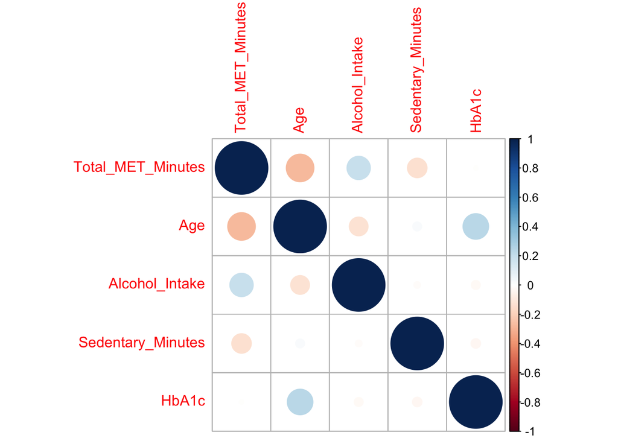

No multicollinearity was found.

## 3.3. Variables distribution

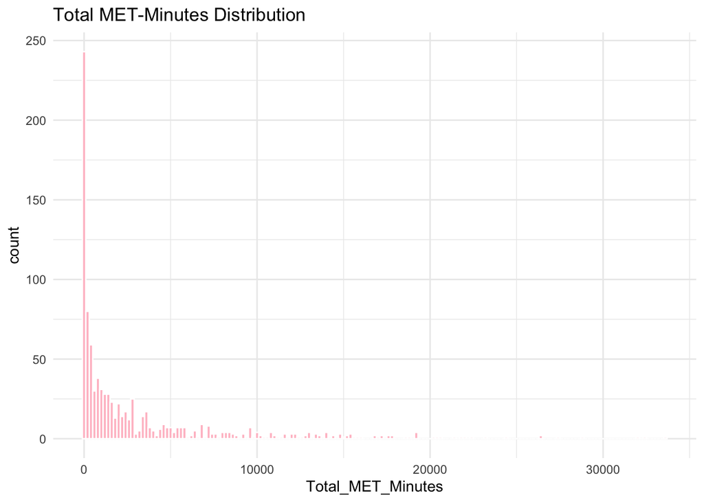

Outliers detection is needed.